# 데이터 분석 시각화 커리큘럼

1주차

Author

최요한

Published

May 22, 2026

## 1 엑셀의 제약사항과 한계

**Note**

엑셀은 장점이 많고 데이터 분석의 토대가 되는 대체불가능한 데이터 분석 도구입니다.

그러나 분석의 규모가 커지고 복잡도가 높아질수록 아래와 같은 한계에 직면하게 됩니다.

#### **대용량 데이터 처리 불가**

> - 약 100만 개 이상의 데이터는 파일에 담을 수 없어 `빅 데이터`, `로그 데이터` 처리에 한계가 있습니다.

#### **연산 속도 및 성능 저하**

> - 함수가 참조하는 값이 많아질수록 처리 속도가 기하급수적으로 지연됩니다

#### **분석 과정의 휘발성과 낮은 재현성**

> - 분석 과정이 대화상자, 메뉴 클릭 등에 의존적이라 분석 과정이 휘발돼 재현성이 떨어집니다

#### **분석 품질의 편차와 검증의 어려움**

> - 재현성이 떨어지므로 개인의 역량에 따라 분석 품질에 편차가 발생합니다.

#### **업무 자동화 및 확장성의 한계**

> - 결과 검증도 어려워 자동화할수 있는 부분도 제한적입니다.

## 2 데이터 처리 방식

#### **이것은 GUI 방식의 한계이기도 합니다.**

데이터를 다루는 방식에는 크게 GUI와 CLI가 있습니다.

#### GUI vs CLI 차이

|  | **Graphic User Interface (GUI)** | Command Line Interface (CLI) |
| --- | --- | --- |
| 정의 | 사용자가 화면에 있는 **아이콘, 메뉴, 버튼 등 그래픽 요소**를 마우스로 클릭해 동작시키는 방식 | 그래픽 화면 없이, **텍스트 형태의 명령어(Code)**를직접 키보드로 타이핑해 동작시키는 방식 |
| 대표 예시 | Excel(엑셀), 웹 브라우저(크롬/사파리), 스마트폰 앱 등 | Windows의 명령 프롬프트(CMD), R, Python 등 |
| 성능 | **그래픽을 화면**에 띄워야 하므로 컴퓨터의 메모리(RAM)와 그래픽 자원을 상대적으로 더 많이 소모함 | **명령어를 순서대로 적어둔 스크립트(code)에 따라 실행**함으로 연산 처리 속도가 상대적으로 매우 빠름 |
| 자동화 | 매번 마우스로 클릭해야 하므로, 수백 개의 파일을 동시에 처리하는 등의 반복 작업을 자동화하기 어려움 | 복잡한 작업도 순서대로 동작하는 코드를 활용해 언제든 다시 실행할 수 있어 자동화에 적합함 |

## 3 도구에 종속되는 사고의 깊이

#### 도구는 사고의 틀을 고정하고, 사고의 깊이는 도구에 종속됩니다.

> 단순히 “속도가 빠르다”거나 “반복 작업을 줄여준다”는 성능의 차이보다 더 중요한 본질입니다

#### datasauRus: 엑셀

#### datasauRus의 dino 데이터셋을 차트로 그릴 때 엑셀이 기본적으로 보여주는 막대 그래프

막대 그래프

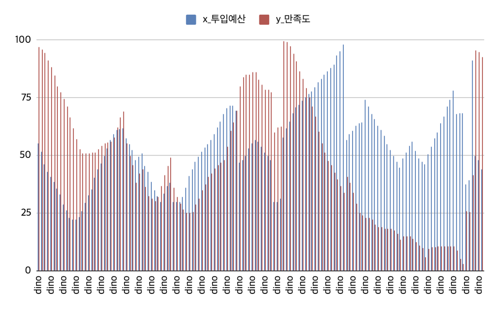

분산형 그래프

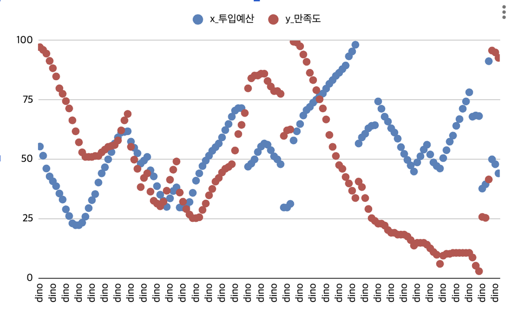

> - 막대그래프는 직관적이지만 x축은 의미가 없고(dino), 이해하기 어려울뿐더러 무의식적으로 시간순서대로 접근하게 됩니다
> - 차트를 분산형으로 변경해도 x축과 y축을 엑셀이 자동으로 설정하므로, 보여지는 모습에서 의미를 더듬어가야 합니다.

#### datasauRus: R

#### 데이터 과학 도구인 R로 시각화한 그래프

```r
library(datasauRus)
datasaurus_dozen |>
  filter(dataset == 'dino') |>
  ggplot(aes(x = x, y = y)) +
  geom_point() +
  #facet_wrap(.~dataset) +
  theme(
    strip.text = element_text(size = 18)
  )
```

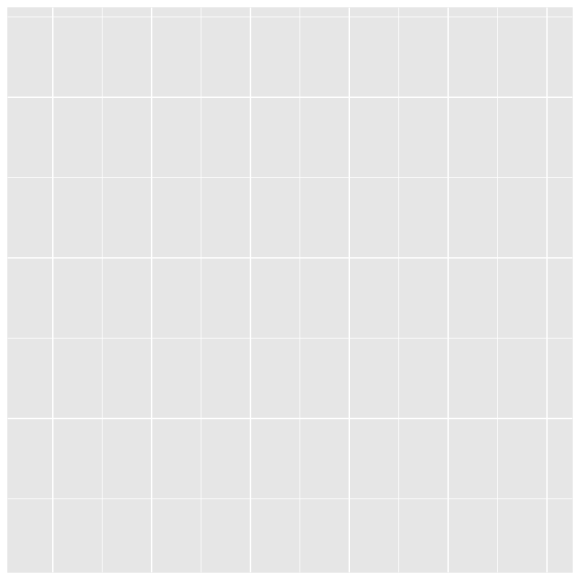

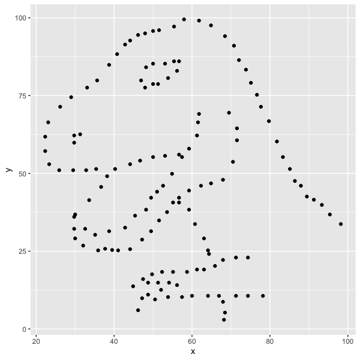

**Important**

- 기본값이 없기 때문에 처음엔 회색 바탕화면만 보이지만 이것은 틀에 갇히지 않는다는 의미입니다.
- 사실 dino 데이터셋은 시각화의 중요성을 강조하기위해 공룡을 시각화한 그래프입니다
- code를 순차적으로 실행해 시각화하므로 누구나 동일한 그래프를 출력할수 있습니다
- code가 보존되어 있다면 언제나 동일한 결과를 출력합니다
- 보이는 것을 보거나, 보여주는 것만을 보는 것으로는 부족합니다
- 보이는 것을 통해 보이지 않는 것도 볼수 있어야 합니다.
- 그것은 무엇을 볼 것인지인지부터 탐색할 때 가능합니다.

## 4 도구에 종속되는 관점

#### 엑셀은 사용자를 배려하기 위해 ’추천 차트’나 ’기본 레이아웃’을 제공합니다.

#### 하지만 역설적으로 이러한 배려와 편리는 분석하려는 사람의 관점을 제한하는 반작용을 불러옵니다.

> 엑셀은 장점이 많고 데이터 분석의 토대가 되는 대체불가능한 분석 도구입니다.

> 하지만 일정 수준 이상의 분석 역량은 ’엑셀’보다 더 나은 분석 도구를 필요로합니다.

> 우리가 7주동안 배우려는 ’R’이 여기에 가장 적합한 도구입니다

## 5 데이터분석 커리큘럼

🔗 [홈페이지](https://www.ngokcoc.or.kr/bbs/board.php?bo_table=news01&wr_id=2124&&page=2&type=&gr_id=media)

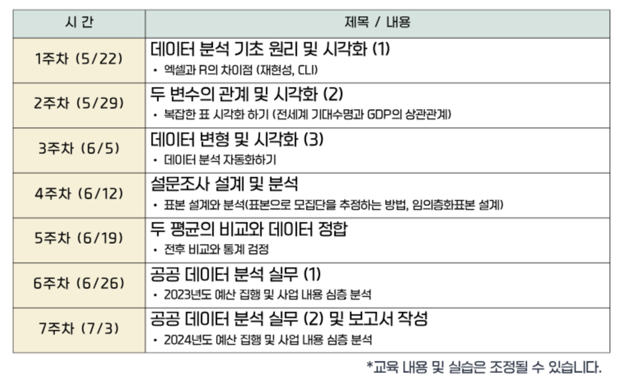

끝.